# Segundo Trabalho de Econometria I - Modelos GARCH

Lucas Rafael de Andrade

# Carregamento de Pacotes

```r
# Language: BRAZILIAN PORTUGUESE [PT-BR]

###################################################################################
#install.packages(c("quantmod", "rugarch", "tseries", "FinTS", "moments", "ggplot2", "gridExtra"))
###################################################################################

library(quantmod)
library(rugarch)
library(tseries)
library(FinTS)
library(moments)
library(ggplot2)
library(gridExtra)
library(knitr)
library(kableExtra)
library(reshape2)
```

# Exercício 1: Modelagem GARCH Linear - Ouro (GC=F)

## 1. Preparação dos Dados

### 1.1 Download e Cálculo dos Retornos

```r
# dados do Ouro
getSymbols("GC=F", from = "2019-01-01", to = "2024-10-31", src = "yahoo")
```

```
## [1] "GC=F"
```

```r
ouro <- na.omit(`GC=F`) #tiro os vaizoz

# preços de fechamento
preco_ouro <- Cl(ouro)

# log-ret x 100 ##  ##   ###    ##   #####
retornos_ouro <- diff(log(preco_ouro)) * 100
retornos_ouro <- na.omit(retornos_ouro)

# basicos ######################################
n_obs_ouro <- length(retornos_ouro)
cat("Número de observações:", n_obs_ouro, "\n")
```

```
## Número de observações: 1467
```

```r
cat("Período:", min(index(retornos_ouro)), "até", max(index(retornos_ouro)), "\n")
```

```
## Período: 17899 até 20026
```

### 1.2 Justificativa da Escolha do Ativo

Escolhi o Ouro por ser:

- Ativo Refúgio: Historicamente utilizado como proteção contra incerteza econômica e inflação
- Alta Liquidez: Mercado futuro extremamente líquido e ativo 24 horas
- Volatilidade Moderada: Apresenta clusters de volatilidade especialmente em períodos de crise
- Relevância Macroeconômica: Sensível a políticas monetárias e eventos geopolíticos

## 2. Análise Exploratória

### 2.1 Gráficos de Preços e Retornos

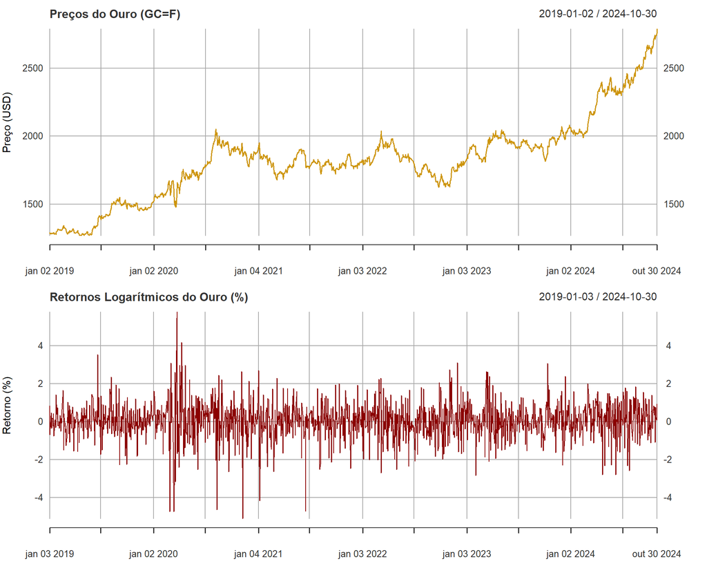

```r
par(mfrow=c(2,1))

# Grafic preços >>>>>>>>>>>>>>>>>>>>>>>>>>>>>>>>>>>>>>>>>>>
plot(preco_ouro, main = "Preços do Ouro (GC=F)", ylab = "Preço (USD)", col = "darkgoldenrod3", lwd = 1.5)

# Grafic retornos >>>>>>>>>>>>>>>>>>>>>>>>>>>>>>>>>>>>>>>>>>>>
plot(retornos_ouro, main = "Retornos Logarítmicos do Ouro (%)", ylab = "Retorno (%)", col = "darkred", lwd = 1)
abline(h = 0, col = "black", lty = 2)
```

### 2.2 Estatísticas Descritivas

```r
estat_ouro <- data.frame(
  Média = mean(retornos_ouro),
  Desvio_Padrão = sd(retornos_ouro),
  Mínimo = min(retornos_ouro),
  Máximo = max(retornos_ouro),
  Assimetria = skewness(retornos_ouro),
  Curtose = kurtosis(retornos_ouro),
  Curtose_Excesso = kurtosis(retornos_ouro) - 3
)

kable(estat_ouro, digits = 4, caption = "Estatísticas Descritivas - Retornos do Ouro")
```

Estatísticas Descritivas - Retornos do Ouro

|  | Média | Desvio_Padrão | Mínimo | Máximo | Assimetria | Curtose | Curtose_Excesso |
| --- | --- | --- | --- | --- | --- | --- | --- |
| GC=F.Close | 0.053 | 0.9749 | -5.1069 | 5.7775 | -0.2616 | 6.9684 | 3.9684 |

```r
# Interpretç
cat("\nInterpretação:\n")
```

```
##
## Interpretação:
```

```r
cat("- Média dos retornos:", round(estat_ouro$Média, 4), "%\n")
```

```
## - Média dos retornos: 0.053 %
```

```r
cat("- Volatilidade (desvio padrão):", round(estat_ouro$Desvio_Padrão, 4), "%\n")
```

```
## - Volatilidade (desvio padrão): 0.9749 %
```

```r
cat("- Assimetria:", round(estat_ouro$Assimetria, 4),
    ifelse(estat_ouro$Assimetria < 0, "(negativa - cauda esquerda mais pesada)\n",
           "(positiva - cauda direita mais pesada)\n"))
```

```
## - Assimetria: -0.2616 (negativa - cauda esquerda mais pesada)
```

```r
cat("- Curtose em excesso:", round(estat_ouro$Curtose_Excesso, 4),
    ifelse(estat_ouro$Curtose_Excesso > 0, "(leptocúrtica - caudas pesadas)\n",
           "(platicúrtica - caudas leves)\n"))
```

```
## - Curtose em excesso: 3.9684 (leptocúrtica - caudas pesadas)
```

### 2.3 Histograma e Q-Q Plot

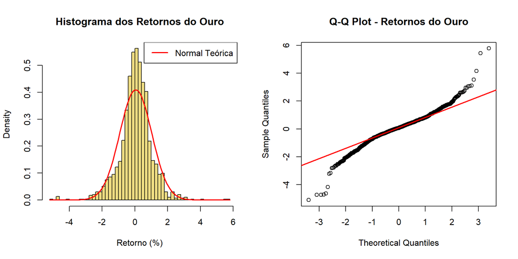

```r
par(mfrow=c(1,2))

# Histogram
hist(retornos_ouro, breaks = 50, freq = FALSE,
     main = "Histograma dos Retornos do Ouro",
     xlab = "Retorno (%)", col = "lightgoldenrod2")
curve(dnorm(x, mean = mean(retornos_ouro), sd = sd(retornos_ouro)),
      add = TRUE, col = "red", lwd = 2)
legend("topright", legend = "Normal Teórica", col = "red", lwd = 2)

# Q-Q Plot
qqnorm(retornos_ouro, main = "Q-Q Plot - Retornos do Ouro")
qqline(retornos_ouro, col = "red", lwd = 2)
```

### 2.4 Testes de Estacionariedade

```r
# Teste ADF(raiz unit)
adf_ouro <- adf.test(retornos_ouro)

# Teste KPSS
kpss_ouro <- kpss.test(retornos_ouro)

cat("Teste ADF (Augmented Dickey-Fuller):\n")
```

```
## Teste ADF (Augmented Dickey-Fuller):
```

```r
cat("H0: Série possui raiz unitária (não estacionária)\n")
```

```
## H0: Série possui raiz unitária (não estacionária)
```

```r
cat("Estatística:", round(adf_ouro$statistic, 4), "\n")
```

```
## Estatística: -11.3045
```

```r
cat("P-valor:", round(adf_ouro$p.value, 4), "\n")
```

```
## P-valor: 0.01
```

```r
cat("Conclusão:", ifelse(adf_ouro$p.value < 0.05,
                         "Rejeita H0 - Série é ESTACIONÁRIA\n\n",
                         "Não rejeita H0 - Série é NÃO ESTACIONÁRIA\n\n"))
```

```
## Conclusão: Rejeita H0 - Série é ESTACIONÁRIA
```

```r
cat("Teste KPSS:\n")
```

```
## Teste KPSS:
```

```r
cat("H0: Série é estacionária\n")
```

```
## H0: Série é estacionária
```

```r
cat("Estatística:", round(kpss_ouro$statistic, 4), "\n")
```

```
## Estatística: 0.1323
```

```r
cat("P-valor:", round(kpss_ouro$p.value, 4), "\n")
```

```
## P-valor: 0.1
```

```r
cat("Conclusão:", ifelse(kpss_ouro$p.value > 0.05,
                         "Não rejeita H0 - Série é ESTACIONÁRIA\n",
                         "Rejeita H0 - Série é NÃO ESTACIONÁRIA\n"))
```

```
## Conclusão: Não rejeita H0 - Série é ESTACIONÁRIA
```

### 2.5 Fatos Estilizados

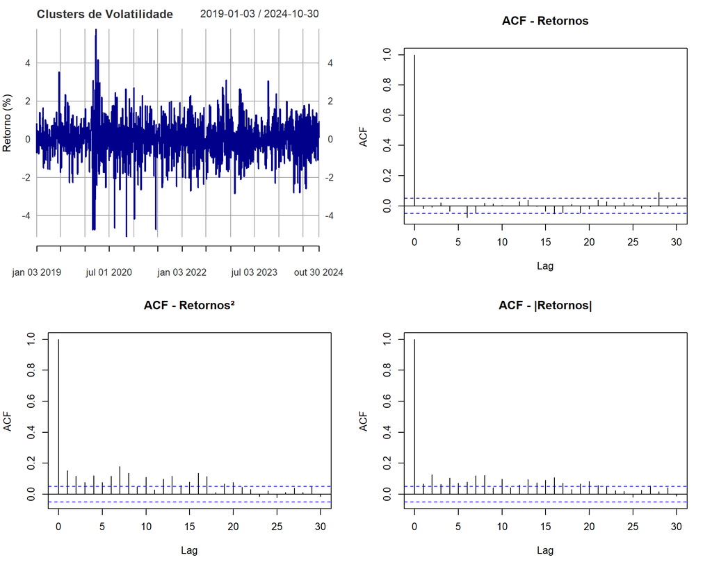

```r
par(mfrow=c(2,2))

# vol cluster
plot(retornos_ouro, main = "Clusters de Volatilidade",
     ylab = "Retorno (%)", col = "darkblue")

# ACF dos retornos
acf(retornos_ouro, main = "ACF - Retornos", lag.max = 30)

# ACF dos retornos ^ quadrado
acf(retornos_ouro^2, main = "ACF - Retornos²", lag.max = 30)

# ACF dos retornos em |valor absoluto|
acf(abs(retornos_ouro), main = "ACF - |Retornos|", lag.max = 30)
```

```r
# Teste ARCH-LM para heterosedasticidade
arch_test_ouro <- ArchTest(retornos_ouro, lags = 12)
cat("\nTeste ARCH-LM (heterocedasticidade):\n")
```

```
##
## Teste ARCH-LM (heterocedasticidade):
```

```r
cat("H0: Não há efeitos ARCH\n")
```

```
## H0: Não há efeitos ARCH
```

```r
cat("Estatística LM:", round(arch_test_ouro$statistic, 4), "\n")
```

```
## Estatística LM: 119.3087
```

```r
cat("P-valor:", round(arch_test_ouro$p.value, 6), "\n")
```

```
## P-valor: 0
```

```r
cat("Conclusão:", ifelse(arch_test_ouro$p.value < 0.05,
                         "Rejeita H0 - Presença de efeitos ARCH (heterocedasticidade condicional)\n",
                         "Não rejeita H0 - Sem evidência de efeitos ARCH\n"))
```

```
## Conclusão: Rejeita H0 - Presença de efeitos ARCH (heterocedasticidade condicional)
```

**Fatos estilizados Identificados:**

1.Clusters de Volatilidade: Períodos de alta volatilidade seguidos por alta volatilidade 2. Caudas Pesadas: Curtose em excesso indica eventos extremos mais frequentes que distribuição normal 3. Autocorrelação nos Quadrados: Evidência de dependência temporal na variância 4. Heterocedasticidade Condicional: Confirmada pelo teste ARCH-LM

## 3. Modelagem GARCH(1,1) Linear

### 3.1 Especificação e Estimação

```r
# Especificação GARCH(1,1) com distribuição t-Student
spec_garch_ouro <- ugarchspec(
  variance.model = list(model = "sGARCH", garchOrder = c(1, 1)),
  mean.model = list(armaOrder = c(0, 0), include.mean = TRUE),
  distribution.model = "std"
)

# Estimaç
fit_garch_ouro <- ugarchfit(spec = spec_garch_ouro, data = retornos_ouro)

# Results
print(fit_garch_ouro)
```

```
##
## *---------------------------------*
## *          GARCH Model Fit        *
## *---------------------------------*
##
## Conditional Variance Dynamics
## -----------------------------------
## GARCH Model  : sGARCH(1,1)
## Mean Model   : ARFIMA(0,0,0)
## Distribution : std
##
## Optimal Parameters
## ------------------------------------
##         Estimate  Std. Error  t value Pr(>|t|)
## mu      0.078152    0.020892   3.7407 0.000184
## omega   0.022554    0.011142   2.0243 0.042941
## alpha1  0.040392    0.011670   3.4610 0.000538
## beta1   0.940063    0.018215  51.6085 0.000000
## shape   4.091080    0.505610   8.0914 0.000000
##
## Robust Standard Errors:
##         Estimate  Std. Error  t value Pr(>|t|)
## mu      0.078152    0.020668   3.7812 0.000156
## omega   0.022554    0.011097   2.0324 0.042118
## alpha1  0.040392    0.015894   2.5413 0.011044
## beta1   0.940063    0.021532  43.6596 0.000000
## shape   4.091080    0.517791   7.9010 0.000000
##
## LogLikelihood : -1918.182
##
## Information Criteria
## ------------------------------------
##
## Akaike       2.6219
## Bayes        2.6400
## Shibata      2.6219
## Hannan-Quinn 2.6287
##
## Weighted Ljung-Box Test on Standardized Residuals
## ------------------------------------
```

[output cut: 40 more lines]

```
## Negative Sign Bias  0.3338 0.7386
## Positive Sign Bias  0.6673 0.5047
## Joint Effect        3.2692 0.3520
##
##
## Adjusted Pearson Goodness-of-Fit Test:
## ------------------------------------
##   group statistic p-value(g-1)
## 1    20     25.61       0.1414
## 2    30     30.36       0.3961
## 3    40     49.43       0.1223
## 4    50     57.51       0.1893
##
##
## Elapsed time : 0.141211
```

### 3.2 Justificativa da Distribuição t-Student

Justificativa para uso da distribuição t-Student:

```r
cat("1. Curtose em excesso observada:", round(estat_ouro$Curtose_Excesso, 4), "\n")
```

```
## 1. Curtose em excesso observada: 3.9684
```

```r
cat("   - Indica caudas mais pesadas que a distribuição normal\n\n")
```

```
##    - Indica caudas mais pesadas que a distribuição normal
```

```r
cat("2. Graus de liberdade estimados:", round(coef(fit_garch_ouro)["shape"], 4), "\n")
```

```
## 2. Graus de liberdade estimados: 4.0911
```

```r
cat("   - Valores baixos (< 30) confirmam necessidade de t-Student\n\n")
```

```
##    - Valores baixos (< 30) confirmam necessidade de t-Student
```

```r
cat("3. A t-Student captura melhor:\n")
```

```
## 3. A t-Student captura melhor:
```

```r
cat("   - Eventos extremos (crashes e rallies)\n")
```

```
##    - Eventos extremos (crashes e rallies)
```

```r
cat("   - Kurtosis excessivo dos retornos financeiros\n")
```

```
##    - Kurtosis excessivo dos retornos financeiros
```

### 3.3 Interpretação dos Parâmetros

Parâmetros Estimados:

```r
coefs_ouro <- coef(fit_garch_ouro)

cat("EQUAÇÃO DA MÉDIA:\n")
```

```
## EQUAÇÃO DA MÉDIA:
```

```r
cat("mu (μ):", round(coefs_ouro["mu"], 6), "\n")
```

```
## mu (μ): 0.078152
```

```r
cat("  - Retorno médio incondicional:", round(coefs_ouro["mu"], 4), "%\n\n")
```

```
##   - Retorno médio incondicional: 0.0782 %
```

```r
cat("EQUAÇÃO DA VARIÂNCIA:\n")
```

```
## EQUAÇÃO DA VARIÂNCIA:
```

```r
cat("omega (ω):", round(coefs_ouro["omega"], 8), "\n")
```

```
## omega (ω): 0.02255393
```

```r
cat("  - Constante (nível base da variância)\n\n")
```

```
##   - Constante (nível base da variância)
```

```r
cat("alpha (α):", round(coefs_ouro["alpha1"], 6), "\n")
```

```
## alpha (α): 0.040392
```

```r
cat("  - Efeito ARCH: impacto de choques passados\n")
```

```
##   - Efeito ARCH: impacto de choques passados
```

```r
cat("  - Representa", round(coefs_ouro["alpha1"]*100, 2), "% do impacto de ε²(t-1)\n\n")
```

```
##   - Representa 4.04 % do impacto de ε²(t-1)
```

```r
cat("beta (β):", round(coefs_ouro["beta1"], 6), "\n")
```

```
## beta (β): 0.940063
```

```r
cat("  - Efeito GARCH: persistência da volatilidade\n")
```

```
##   - Efeito GARCH: persistência da volatilidade
```

```r
cat("  - Representa", round(coefs_ouro["beta1"]*100, 2), "% da persistência de σ²(t-1)\n\n")
```

```
##   - Representa 94.01 % da persistência de σ²(t-1)
```

```r
soma_ab <- coefs_ouro["alpha1"] + coefs_ouro["beta1"]
cat("Soma α + β:", round(soma_ab, 6), "\n")
```

```
## Soma α + β: 0.980454
```

```r
cat("  - Persistência total:", round(soma_ab*100, 2), "%\n")
```

```
##   - Persistência total: 98.05 %
```

```r
cat("  - Condição de estacionariedade (α + β < 1):",
    ifelse(soma_ab < 1, "SATISFEITA ✓\n", "NÃO SATISFEITA ✗\n"))
```

```
##   - Condição de estacionariedade (α + β < 1): SATISFEITA ✓
```

```r
cat("  - Half-life (meia-vida):", round(log(0.5)/log(soma_ab), 2), "dias\n\n")
```

```
##   - Half-life (meia-vida): 35.12 dias
```

```r
cat("shape (ν):", round(coefs_ouro["shape"], 4), "\n")
```

```
## shape (ν): 4.0911
```

```r
cat("  - Graus de liberdade da t-Student\n")
```

```
##   - Graus de liberdade da t-Student
```

```r
cat("  - Quanto menor, mais pesadas as caudas\n")
```

```
##   - Quanto menor, mais pesadas as caudas
```

### 3.4 Significância Estatística

```r
#  estatsticas do modelo
stats_ouro <- data.frame(
  Parâmetro = names(coef(fit_garch_ouro)),
  Estimativa = coef(fit_garch_ouro),
  Erro_Padrão = fit_garch_ouro@fit$matcoef[, 2],
  Estatística_t = fit_garch_ouro@fit$matcoef[, 3],
  P_valor = fit_garch_ouro@fit$matcoef[, 4]
)

kable(stats_ouro, digits = 6, caption = "Significância Estatística dos Parâmetros - Ouro")
```

Significância Estatística dos Parâmetros - Ouro

|  | Parâmetro | Estimativa | Erro_Padrão | Estatística_t | P_valor |
| --- | --- | --- | --- | --- | --- |
| mu | mu | 0.078152 | 0.020892 | 3.740704 | 0.000184 |
| omega | omega | 0.022554 | 0.011142 | 2.024281 | 0.042941 |
| alpha1 | alpha1 | 0.040392 | 0.011670 | 3.461027 | 0.000538 |
| beta1 | beta1 | 0.940063 | 0.018215 | 51.608514 | 0.000000 |
| shape | shape | 4.091080 | 0.505610 | 8.091378 | 0.000000 |

```r
cat("\nTodos os parâmetros com p-valor < 0.05 são estatisticamente significativos ao nível de 5%\n")
```

```
##
## Todos os parâmetros com p-valor < 0.05 são estatisticamente significativos ao nível de 5%
```

## 4. Diagnóstico do Modelo

### 4.1 Resíduos Padronizados

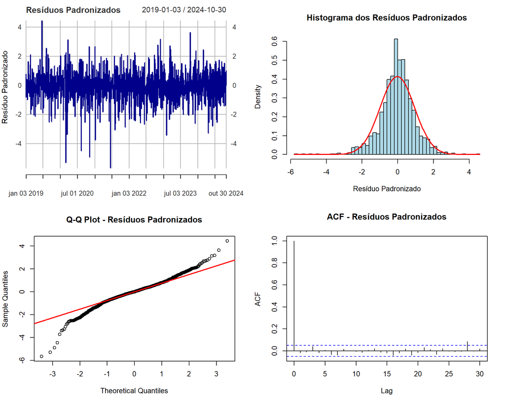

```r
# Extração de resíduos padronizados
residuos_pad_ouro <- residuals(fit_garch_ouro, standardize = TRUE)

par(mfrow=c(2,2))

# Gráfico dos resídos
plot(residuos_pad_ouro, main = "Resíduos Padronizados",
     ylab = "Resíduo Padronizado", col = "darkblue")
abline(h = 0, col = "red", lty = 2)
abline(h = c(-2, 2), col = "orange", lty = 2)

# Histogrm
hist(residuos_pad_ouro, breaks = 50, freq = FALSE,
     main = "Histograma dos Resíduos Padronizados",
     xlab = "Resíduo Padronizado", col = "lightblue")
curve(dnorm(x, mean = mean(residuos_pad_ouro), sd = sd(residuos_pad_ouro)),
      add = TRUE, col = "red", lwd = 2)

# Q-Q Plot
qqnorm(residuos_pad_ouro, main = "Q-Q Plot - Resíduos Padronizados")
qqline(residuos_pad_ouro, col = "red", lwd = 2)

# ACF
acf(residuos_pad_ouro, main = "ACF - Resíduos Padronizados", lag.max = 30)
```

### 4.2 Teste de Autocorrelação (Ljung-Box)

```r
# Testes LB para diferentes lags
lags <- c(5, 10, 15)
resultados_lb_ouro <- data.frame()

for (lag in lags) {
  teste <- Box.test(residuos_pad_ouro, lag = lag, type = "Ljung-Box")
  resultados_lb_ouro <- rbind(resultados_lb_ouro,
                               data.frame(
                                 Lag = lag,
                                 Estatística = teste$statistic,
                                 P_valor = teste$p.value,
                                 Conclusão = ifelse(teste$p.value > 0.05,
                                                    "Não rejeita H0", "Rejeita H0")
                               ))
}

kable(resultados_lb_ouro, digits = 4,
      caption = "Teste Ljung-Box - Autocorrelação dos Resíduos")
```

Teste Ljung-Box - Autocorrelação dos Resíduos

|  | Lag | Estatística | P_valor | Conclusão |
| --- | --- | --- | --- | --- |
| X-squared | 5 | 3.3727 | 0.6427 | Não rejeita H0 |
| X-squared1 | 10 | 7.6935 | 0.6588 | Não rejeita H0 |
| X-squared2 | 15 | 9.6562 | 0.8408 | Não rejeita H0 |

```r
cat("\nH0: Não há autocorrelação nos resíduos\n")
```

```
##
## H0: Não há autocorrelação nos resíduos
```

```r
cat("Interpretação: P-valores > 0.05 indicam ausência de autocorrelação significativa\n")
```

```
## Interpretação: P-valores > 0.05 indicam ausência de autocorrelação significativa
```

### 4.3 Teste de Normalidade <- Jarque-Bera

```r
jb_test_ouro <- jarque.test(as.numeric(residuos_pad_ouro))

cat("Teste Jarque-Bera:\n")
```

```
## Teste Jarque-Bera:
```

```r
cat("H0: Resíduos seguem distribuição normal\n")
```

```
## H0: Resíduos seguem distribuição normal
```

```r
cat("Estatística:", round(jb_test_ouro$statistic, 4), "\n")
```

```
## Estatística: 584.9715
```

```r
cat("P-valor:", format(jb_test_ouro$p.value, scientific = TRUE, digits = 4), "\n")
```

```
## P-valor: 0e+00
```

```r
cat("Conclusão:", ifelse(jb_test_ouro$p.value < 0.05,
                         "Rejeita H0 - Resíduos NÃO são normais (esperado para t-Student)\n",
                         "Não rejeita H0 - Resíduos são normais\n"))
```

```
## Conclusão: Rejeita H0 - Resíduos NÃO são normais (esperado para t-Student)
```

### 4.4 Teste ARCH-LM nos Resíduos

```r
arch_test_res_ouro <- ArchTest(residuos_pad_ouro, lags = 12)

cat("Teste ARCH-LM nos Resíduos Padronizados:\n")
```

```
## Teste ARCH-LM nos Resíduos Padronizados:
```

```r
cat("H0: Não há efeitos ARCH nos resíduos\n")
```

```
## H0: Não há efeitos ARCH nos resíduos
```

```r
cat("Estatística LM:", round(arch_test_res_ouro$statistic, 4), "\n")
```

```
## Estatística LM: 13.532
```

```r
cat("P-valor:", round(arch_test_res_ouro$p.value, 4), "\n")
```

```
## P-valor: 0.3316
```

```r
cat("Conclusão:", ifelse(arch_test_res_ouro$p.value > 0.05,
                         "Não rejeita H0 - Modelo capturou adequadamente a heterocedasticidade\n",
                         "Rejeita H0 - Ainda há efeitos ARCH residuais\n"))
```

```
## Conclusão: Não rejeita H0 - Modelo capturou adequadamente a heterocedasticidade
```